# Airbnb_NYC_2019_Final-Copy2

```python
from traitlets.config import Config
import nbformat as nbf
from nbconvert.exporters import HTMLExporter
#c = Config()
# Configure our tag removal
#c.TagRemovePreprocessor.remove_cell_tags = ("remove_cell",)
#c.TagRemovePreprocessor.remove_all_outputs_tags = ('remove_output',)
#c.TagRemovePreprocessor.remove_input_tags = ('remove_input',)
# Configure and run out exporter
#c.HTMLExporter.preprocessors = ["TagRemovePreprocessor"]
#HTMLExporter(config=c).from_filename("/Users/Gregs_Computer/Documents/Studies/Data_Science/Projects/Airbnb NYC/Airbnb_NYC_2019_Final-Copy2.ipynb")

#{
#"tags": [
#    "remove_cell",
#]
#}
```

[figure not shown]

```python
!jupyter nbconvert Airbnb_NYC_2019_Final-Copy2.ipynb --to html --output example.html --TagRemovePreprocessor.remove_cell_tags="['remove_cell']"
```

```
[NbConvertApp] Converting notebook Airbnb_NYC_2019_Final-Copy2.ipynb to html
[NbConvertApp] Writing 3859251 bytes to example.html
```

## Introduction

The independent variable of the data is price, which is the price per listing per night.

In order to improve prediction accuracy and limit our data to more standard Airbnb listings, we will remove outlier data from extremely luxurious listings that are astronomically more expensive than more standard Airbnb's. The maximum price/night we will use is the tukey outlier threshold of $323 as we will see below.

## Goals of the Project

The goal of this project is to create a machine learning model that can predict the price of a standard Airbnb in New York City based on the listing's features and amenities in the dataset (ie # bedrooms, TV, WiFi, etc). We will also analyze the listings data using exploratory data analysis to pull insights that will help Airbnb to raise revenues and increase efficiency.

# Importing the Data

Data retrieved from: http://insideairbnb.com/get-the-data.html.

Here we view the first 5 rows of the DataFrame to get an idea of the data's layout and features.

```python
# Import Listings Data
listings_original = pd.read_csv(os.path.join(PROJECT_ROOT_DIR, 'Data', 'listings.csv'))
listings_original.head()
```

|  | id | listing_url | scrape_id | last_scraped | name | summary | space | description | experiences_offered | neighborhood_overview | notes | transit | access | interaction | house_rules | thumbnail_url | medium_url | picture_url | xl_picture_url | host_id | host_url | host_name | host_since | host_location | host_about | host_response_time | host_response_rate | host_acceptance_rate | host_is_superhost | … |
| --- | --- | --- | --- | --- | --- | --- | --- | --- | --- | --- | --- | --- | --- | --- | --- | --- | --- | --- | --- | --- | --- | --- | --- | --- | --- | --- | --- | --- | --- | --- |
| 0 | 2539 | https://www.airbnb.com/rooms/2539 | 20190602163209 | 2019-06-03 | Clean & quiet apt home by the park | Renovated apt home in elevator building. | Spacious, renovated, and clean apt home, one b... | Renovated apt home in elevator building. Spaci... | none | Close to Prospect Park and Historic Ditmas Park | If this room is unavailable on your desired da... | Very close to F and G trains and Express bus i... | NaN | NaN | -The security and comfort of all our guests is... | NaN | NaN | https://a0.muscache.com/im/pictures/3949d073-a... | NaN | 2787 | https://www.airbnb.com/users/show/2787 | John | 2008-09-07 | New York, New York, United States | Educated professional living in Brooklyn. I l... | within an hour | 100% | NaN | f | … |
| 1 | 2595 | https://www.airbnb.com/rooms/2595 | 20190602163209 | 2019-06-03 | Skylit Midtown Castle | Find your romantic getaway to this beautiful, ... | - Spacious (500+ft²), immaculate and nicely fu... | Find your romantic getaway to this beautiful, ... | none | Centrally located in the heart of Manhattan ju... | NaN | Apartment is located on 37th Street between 5t... | Guests have full access to the kitchen, bathro... | I am a Sound Therapy Practitioner and Kundalin... | Make yourself at home, respect the space and t... | NaN | NaN | https://a0.muscache.com/im/pictures/f0813a11-4... | NaN | 2845 | https://www.airbnb.com/users/show/2845 | Jennifer | 2008-09-09 | New York, New York, United States | A New Yorker since 2000! My passion is creatin... | within a few hours | 83% | NaN | f | … |
| 2 | 3647 | https://www.airbnb.com/rooms/3647 | 20190602163209 | 2019-06-03 | THE VILLAGE OF HARLEM....NEW YORK ! | NaN | WELCOME TO OUR INTERNATIONAL URBAN COMMUNITY T... | WELCOME TO OUR INTERNATIONAL URBAN COMMUNITY T... | none | NaN | NaN | NaN | NaN | NaN | Upon arrival please have a legibile copy of yo... | NaN | NaN | https://a0.muscache.com/im/pictures/838341/9b3... | NaN | 4632 | https://www.airbnb.com/users/show/4632 | Elisabeth | 2008-11-25 | New York, New York, United States | Make Up Artist National/ (Website hidden by Ai... | within a day | 100% | NaN | f | … |
| 3 | 3831 | https://www.airbnb.com/rooms/3831 | 20190602163209 | 2019-06-03 | Cozy Entire Floor of Brownstone | Urban retreat: enjoy 500 s.f. floor in 1899 br... | Greetings! We own a double-duplex brownst... | Urban retreat: enjoy 500 s.f. floor in 1899 br... | none | Just the right mix of urban center and local n... | NaN | B52 bus for a 10-minute ride to downtown Brook... | You will have exclusive use of and access to: ... | We'll be around, but since you have the top fl... | Smoking - outside please; pets allowed but ple... | NaN | NaN | https://a0.muscache.com/im/pictures/e49999c2-9... | NaN | 4869 | https://www.airbnb.com/users/show/4869 | LisaRoxanne | 2008-12-07 | New York, New York, United States | Laid-back bi-coastal actor/professor/attorney. | within an hour | 100% | NaN | f | … |
| 4 | 4989 | https://www.airbnb.com/rooms/4989 | 20190602163209 | 2019-06-03 | Great 1 bdrm. apartment in the PERFECT location! | Best location in NYC (the greatest city in the... | Quiet, artsy, 1 bdrm. apt. in Hell's Kitchen (... | Best location in NYC (the greatest city in the... | none | Hell's Kitchen is a safe, popular, and desirab... | Enjoy! | NYC subways and the Hudson River are each just... | The apt. is all yours. | Reach me via phone, text, email, etc. And I'll... | Keep things clean and orderly and quiet please... | NaN | NaN | https://a0.muscache.com/im/pictures/ebafaaa6-d... | NaN | 7118 | https://www.airbnb.com/users/show/7118 | New-Yorker | 2009-01-26 | New York, New York, United States | Professional Designer/Artist working in Theatr... | within a day | 50% | NaN | f | … |

```python
# Shape of original data
listings_original.shape
```

```
(48801, 106)
```

# Cleaning the Data

We will begin by splitting the data into train and test sets. We will only be observing the training set to avoid any bias from assumptions made based on the testing data. We will not touch the testing data until our final model is ready for production to test its accuracy.

```python
# Copy original DataFrame
listings = listings_original.copy(deep=True)
```

```python
# Create train/test sets
from sklearn.model_selection import train_test_split
listings_train, listings_test = train_test_split(listings.copy(),
                                                 test_size=0.2, random_state=42)
```

```python
# Shape of training data
listings_train.shape
```

```
(39040, 106)
```

We will now copy our training data as an exploratory DataFrame that we can experimentally modify without affecting our original training set.

```python
# Copy listings_train for data exploration
listings_explore = listings_train.copy(deep=True)
```

```python
# dtypes of each feature
#listings_explore.info(verbose=True)
```

### Check for Missing Values

We will now check for missing values by creating a `find_missing_values` function to get an idea of which features require immediate deletion or imputation. As a general rule of thumb used here: if a feature is missing more than 20-30% of its values, it requires immediate deletion because imputation will bias the results too heavily.

```python
# View missing values
def find_missing_values(df, columns):
    '''
    Finds number of rows where certain columns are missing values.
    ::param_df:: = target dataframe (ie train)
    ::param_columns:: = list of columns (train.columns)
    '''
    missing_vals = {}
    print('Number of missing or NaN values for each column:')
    df_length = len(df)
    for column in columns:
        total_column_values = df[column].value_counts().sum()
        missing_vals[column] = df_length - total_column_values
        # missing_vals.append(str(column + ' column has {} missing or NaN values.'.format())
    return missing_vals

missing_values = find_missing_values(listings_explore, listings_explore.columns)
missing_values
```

```
Number of missing or NaN values for each column:
```

```
{'id': 0,
 'listing_url': 0,
 'scrape_id': 0,
 'last_scraped': 0,
 'name': 12,
 'summary': 1567,
 'space': 11387,
 'description': 576,
 'experiences_offered': 0,
 'neighborhood_overview': 14107,
 'notes': 22863,
 'transit': 13711,
 'access': 17065,
 'interaction': 16139,
 'house_rules': 15110,
 'thumbnail_url': 39040,
 'medium_url': 39040,
 'picture_url': 0,
 'xl_picture_url': 39040,
 'host_id': 0,
 'host_url': 0,
 'host_name': 10,
 'host_since': 10,
 'host_location': 129,
 'host_about': 14855,
 'host_response_time': 13133,
 'host_response_rate': 13133,
 'host_acceptance_rate': 39040,
 'host_is_superhost': 10,
 'host_thumbnail_url': 10,
 'host_picture_url': 10,
 'host_neighbourhood': 5228,
 'host_listings_count': 10,
 'host_total_listings_count': 10,
 'host_verifications': 0,
 'host_has_profile_pic': 10,
 'host_identity_verified': 10,
 'street': 0,
 'neighbourhood': 7,
 'neighbourhood_cleansed': 0,
```

[output cut: 51 more lines]

```
 'review_scores_location': 8886,
 'review_scores_value': 8885,
 'requires_license': 0,
 'license': 39029,
 'jurisdiction_names': 39035,
 'instant_bookable': 0,
 'is_business_travel_ready': 0,
 'cancellation_policy': 0,
 'require_guest_profile_picture': 0,
 'require_guest_phone_verification': 0,
 'calculated_host_listings_count': 0,
 'calculated_host_listings_count_entire_homes': 0,
 'calculated_host_listings_count_private_rooms': 0,
 'calculated_host_listings_count_shared_rooms': 0,
 'reviews_per_month': 8084}
```

### Preliminary Feature Elimination

We will now drop features that most obviously exceed the missing value limits or are not useful for our analysis and model.

```python
# Drop obviously unnecessary features
dropped_cols = []
dropped_cols.extend([
 # Unnecessary features:
 'id','host_id','listing_url','scrape_id','last_scraped','name','summary','space','description','neighborhood_overview','notes','transit',
 'access','interaction','house_rules','thumbnail_url','medium_url','picture_url','xl_picture_url','host_url','host_name','host_about',
 # Features with too many missing values:
 'host_response_time','host_response_rate','host_acceptance_rate','host_thumbnail_url','host_picture_url','square_feet',
 'weekly_price','monthly_price','security_deposit','license','jurisdiction_names'
 ])
listings_explore.drop(columns=dropped_cols, inplace=True)
```

# Univariate Feature Cleaning

Now that we have removed the immediately obvious features, we will further explore the values within our remaining features to determine which features to use in our analysis and model. We will do so by checking the top 5 and bottom 5 values and frequencies (`value_count`] of each value in a given feature to better understand what the feature consists of.

**Feature: experiences_offered**

We drop experiences_offered because all values are null.

```python
# Check values for experiences_offered
listings_explore.experiences_offered.value_counts()
```

```
none    39040
Name: experiences_offered, dtype: int64
```

```python
# Drop experiences_offered
listings_explore.drop(columns='experiences_offered', inplace=True)
dropped_cols.append('experiences_offered')
```

**Feature: host_location**

We drop host_location because it seems to be an arbitrary fill-in from the hosts, and their location is not the location of the airbnb's location.

```python
# check values for host_location
print(listings_explore.host_location.value_counts()[:5])
print(listings_explore.host_location.value_counts()[-5:])
```

```
New York, New York, United States         26044
US                                         3954
Brooklyn, New York, United States          2919
Queens, New York, United States             978
Los Angeles, California, United States      234
Name: host_location, dtype: int64
LV                                      1
Springfield, Missouri, United States    1
Findlay, Ohio, United States            1
Glencoe, Illinois, United States        1
St Albert, Alberta, Canada              1
Name: host_location, dtype: int64
```

```python
# Drop host_location
listings_explore.drop(columns='host_location', inplace=True)
dropped_cols.extend(['host_location'])
```

**Feature: street**

We drop street because it doesn't seem to accurately label streets. It's probably manually filled in by the hosts without verification of street names. We can use our other location-based feature(s) instead.

```python
# Check values for street
print(listings_explore.street.value_counts()[:5])
print(listings_explore.street.value_counts()[-5:])
```

```
New York, NY, United States     17722
Brooklyn, NY, United States     15072
Queens, NY, United States        3337
Bronx, NY, United States          653
Brooklyn , NY, United States      613
Name: street, dtype: int64
 New York , NY, United States    1
Brooklyn, MP, United States      1
Regó park , NY, United States    1
PECK SLIP, NY, United States     1
Jamaica, Ny, United States       1
Name: street, dtype: int64
```

```python
# Drop Street
listings_explore.drop(columns='street', inplace=True)
dropped_cols.extend(['street'])
```

**Feature: host_neighbourhood**

Drop because unnecessary host manual fill-in information.

```python
# check values for host_neighbourhood
print(listings_explore.host_neighbourhood.value_counts()[:5])
print(listings_explore.host_neighbourhood.value_counts()[-5:])
```

```
Williamsburg          2801
Bedford-Stuyvesant    2383
Bushwick              1676
Upper East Side       1396
Hell's Kitchen        1388
Name: host_neighbourhood, dtype: int64
Sunny Isles Beach    1
College Park, MD     1
Neukölln             1
Noe Valley           1
San Giovanni         1
Name: host_neighbourhood, dtype: int64
```

```python
# Drop host_neighbourhood
listings_explore.drop(columns='host_neighbourhood', inplace=True)
dropped_cols.append('host_neighbourhood')
```

**Feature: host_verifications**

Drop because this is unnecessary corporate information that is invisible to the renter.

```python
# check values for host_verifications
print(listings_explore.host_verifications.value_counts()[:5])
```

```
['email', 'phone', 'reviews', 'kba']                                                                             4004
['email', 'phone', 'reviews', 'jumio', 'government_id']                                                          3729
['email', 'phone']                                                                                               2774
['email', 'phone', 'reviews']                                                                                    2396
['email', 'phone', 'reviews', 'jumio', 'offline_government_id', 'selfie', 'government_id', 'identity_manual']    1686
Name: host_verifications, dtype: int64
```

```python
# Drop host_verifications
listings_explore.drop(columns='host_verifications', inplace=True)
dropped_cols.append('host_verifications')
```

**Feature: neighbourhood**

Drop because neighbourhood_cleansed and neighbourhood_group_cleansed (features we will keep) are a more accurate/clean version of neighbourhood. neighbourhood is likely a manual host fill-in.

```python
# Check values for neighbourhood
print(listings_explore.neighbourhood.value_counts()[:5])
print(listings_explore.neighbourhood.value_counts()[-5:])
```

```
Brooklyn              8573
Manhattan             8260
Queens                2203
Bedford-Stuyvesant    1520
Williamsburg          1477
Name: neighbourhood, dtype: int64
Todt Hill      1
New Dorp       1
Oakwood        1
Huguenot       1
Eltingville    1
Name: neighbourhood, dtype: int64
```

```python
# Check values for neighbourhood_cleansed
print(listings_explore.neighbourhood_cleansed.value_counts()[:5])
print(listings_explore.neighbourhood_cleansed.value_counts()[-5:])
```

```
Williamsburg          3152
Bedford-Stuyvesant    2960
Harlem                2119
Bushwick              1956
Upper West Side       1655
Name: neighbourhood_cleansed, dtype: int64
Castle Hill    1
Westerleigh    1
Mill Basin     1
Willowbrook    1
Woodrow        1
Name: neighbourhood_cleansed, dtype: int64
```

```python
# Check values for neighbourhood_group_cleansed
listings_explore.neighbourhood_group_cleansed.value_counts()
```

```
Manhattan        17495
Brooklyn         16024
Queens            4409
Bronx              828
Staten Island      284
Name: neighbourhood_group_cleansed, dtype: int64
```

```python
# Drop neighbourhood
listings_explore.drop(columns='neighbourhood', inplace=True)
dropped_cols.append('neighbourhood')
```

**Features: city, state**

Drop city because neighbourhood_cleansed and neighbourhood_group_cleansed describe the city. Drop state because all listings are in the same state. Both are likely host fill-in.

```python
# Check values for city
print(listings_explore.city.value_counts()[:5])
print(listings_explore.city.value_counts()[-5:])
```

```
New York     17722
Brooklyn     15073
Queens        3337
Bronx          653
Brooklyn       613
Name: city, dtype: int64
纽约法拉盛                  1
Brooklyn New York      1
Gravesend Brooklyn     1
Yonkers                1
Woodside, Queens       1
Name: city, dtype: int64
```

```python
# Check values for state
print(listings_explore.state.value_counts()[:5])
print(listings_explore.state.value_counts()[-5:])
```

```
NY    39025
Ny        7
ny        2
CA        1
MP        1
Name: state, dtype: int64
Ny    7
ny    2
CA    1
MP    1
NJ    1
Name: state, dtype: int64
```

```python
# Drop city and state
listings_explore.drop(columns=['city', 'state'], inplace=True)
dropped_cols.extend(['city', 'state'])
```

**Features: market, smart_location, country_code, country**

Drop market and smart_location as neither seem to be accurate representations of listing location. Drop country_code and country because all listings are in the same country.

```python
# Check values for market
print(listings_explore.market.value_counts()[:5])
print(listings_explore.market.value_counts()[-5:])
```

```
New York            38929
Other (Domestic)       12
Adirondacks             2
Agra                    1
Lagos, NG               1
Name: market, dtype: int64
Paris                          1
Cuba                           1
Catskills and Hudson Valley    1
D.C.                           1
Atlanta                        1
Name: market, dtype: int64
```

```python
# Check values for smart_location
print(listings_explore.smart_location.value_counts()[:5])
print(listings_explore.smart_location.value_counts()[-5:])
```

```
New York, NY     17722
Brooklyn, NY     15072
Queens, NY        3337
Bronx, NY          653
Brooklyn , NY      613
Name: smart_location, dtype: int64
Jamaica, Ny                  1
Williamsburg Brooklyn, NY    1
Queens Astoria , NY          1
BRONX, NY                    1
Queens NY, NY                1
Name: smart_location, dtype: int64
```

```python
# Drop 'market', 'smart_location', 'country_code', 'country'
listings_explore.drop(columns=['market', 'smart_location', 'country_code', 'country'], inplace=True)
dropped_cols.extend(['market', 'smart_location', 'country_code', 'country'])
```

**Feature: calendar_last_scraped**

Drop because all listings were scraped within one day of each other.

```python
# Check values for calendar_last_scraped
listings_explore.calendar_last_scraped.value_counts()
```

```
2019-06-03    27851
2019-06-02    11189
Name: calendar_last_scraped, dtype: int64
```

```python
# Drop calendar_last_scraped
listings_explore.drop(columns='calendar_last_scraped', inplace=True)
dropped_cols.append('calendar_last_scraped')
```

**Feature: requires_license**

Drop because all values are False.

```python
# Check values for requires_license
listings_explore.requires_license.value_counts()
```

```
f    39040
Name: requires_license, dtype: int64
```

```python
# Drop requires_license
listings_explore.drop(columns='requires_license', inplace=True)
dropped_cols.append('requires_license')
```

**Feature: is_business_travel_ready**

Drop because all values are False.

```python
# Check values for is_business_travel_ready
listings_explore.is_business_travel_ready.value_counts()
```

```
f    39040
Name: is_business_travel_ready, dtype: int64
```

```python
# Drop is_business_travel_ready
listings_explore.drop(columns='is_business_travel_ready', inplace=True)
dropped_cols.append('is_business_travel_ready')
```

We have finished our preliminary feature cleaning.

```python
# Check current amount of features
len(listings_explore.columns)
```

```
58
```

## Feature Cleaning and Univariate Analysis

Now that we have eliminated preliminary features, we will take a deeper look at each feature and modify as needed.

```python
# Lists of each type of attribute (to be filled as each feature is analyzed)
num_attribs = []
disc_attribs = []
cat_attribs = []
drop_attribs = []
drop_later = []
```

First, we will create a few functions for feature analysis.

```python
# Create dataframe of categorical/numerical variables (for later use)
def num_cat_df(num_attribs, cat_attribs):
    '''
    Creates a dataframe of numerical and categorical attributes.
    '''
    num_df = pd.DataFrame({})
    cat_df = pd.DataFrame({})

    num_df['Numerical'] = num_attribs
    cat_df['Categorical'] = cat_attribs
    var_df = pd.concat([num_df, cat_df], axis=1)
    return var_df
```

```python
# Create function for viewing basic information about each feature
def preliminaries(df, column, values=False):
    '''
    Prints the dtype, missing values, and value counts of a series.

    Args:
    df -- dataframe
    column -- feature column
    values -- display value_counts
    '''
    # Dtype
    print('Dtype: ', df[column].dtype)

    # Missing Values
    df_length = len(df)
    total_column_values = df[column].value_counts().sum()
    missing_vals = df_length - total_column_values
    print('Missing Values: ', missing_vals)

    # Value counts
    if values:
        print(df[column].value_counts())
```

```python
# Function for statistical analysis of each feature
def sum_stats(df_dot_column):
    '''
    Prints basic summary statistics of a given feature:
    nobs, median, mode, mean, std, minmax, 25%, 50%, 75%, skewness

    Args:
    df_dot_column -- Pandas series of given feature
    '''
    sum_stats = scipy.stats.describe(df_dot_column)
    pd_stats = df_dot_column.describe()
    print('nobs:', sum_stats[0])
    print('median:', df_dot_column.median())
    print('mode:', scipy.stats.mode(df_dot_column)[0])
    print('mean:', sum_stats[2])
    print('std:', np.sqrt(sum_stats[3]))
    print('minmax:', sum_stats[1])
    print('25%', pd_stats[4])
    print('50%', pd_stats[5])
    print('75%', pd_stats[6])
    print('skewness:', sum_stats[4])
```

```python
def percentage_of(df_dot_column, value):
    '''
    Calculates a given value's percentage of total values

    Args:
    df_dot_column -- Pandas series
    value -- value to calculate percentage of total
    '''
    return np.round(df_dot_column.value_counts(normalize=True)[value],2)
```

We will now view a visual representation of the distribution of missing values in our DataFrame. This way we can confirm that none of our features have more than 20-30% missing values.

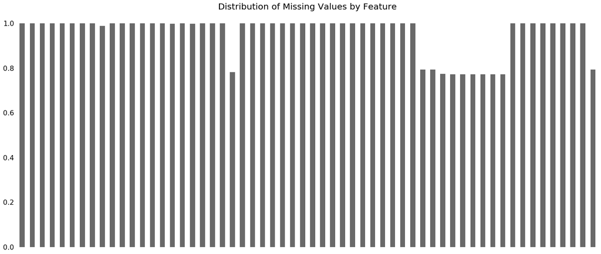

```python
fig = missingno.bar(listings_explore)
plt.title('Distribution of Missing Values by Feature', fontsize=20)
plt.show()
```

## Numerical Features

First, we will analyze the numerical features.

```python
# Function to view tukey outliers
def tukey_outliers(df_dot_column):
    '''
    Function for detecting Tukey outliers using IQR

    data --- dataset
    feature --- string name of feature column

    returns 2 vars: outlier indices & outlier values

    Args:
    df_dot_column -- feature's Pandas series
    '''
    x = df_dot_column
    q1 = np.percentile(x, 25)
    q3 = np.percentile(x, 75)
    iqr = q3-q1
    floor = q1 - 1.5*iqr
    ceiling = q3 + 1.5*iqr
    return floor, ceiling
```

```python
# Function to plot CDF's
def cdf(df, column):
    '''
    Function to plot CDF of a numerical feature

    Args:
    df -- dataframe
    column -- feature name
    '''
    plt.hist(df[column],
             cumulative=True, density=1, histtype='step', bins=len(df[column]))
    plt.show()
```

```python
# Function to find percentile of a score
def percentile(df_dot_column, score):
    '''
    Function to find percentile of a score

    Args:

    df_dot_column -- Pandas series
    score -- score for calculating percentile
    '''
    from scipy.stats import percentileofscore
    return scipy.stats.percentileofscore(df_dot_column, score)
```

## Feature: price (Independent Variable) (numerical)

```python
preliminaries(listings_explore, 'price')
```

```
Dtype:  object
Missing Values:  0
```

```python
# Value counts
print(listings_explore.price.value_counts()[:5])
```

```
$150.00    1670
$100.00    1569
$50.00     1242
$60.00     1165
$200.00    1103
Name: price, dtype: int64
```

As we can see below, many of our numerical features are of dtype string, and have string characters such as "$" that must be removed before converting them to float or int.

```python
# Remove string characters, convert to float
listings_explore['price'] = listings_explore['price'].astype('str').copy()
listings_explore['price'] = listings_explore['price'].str.replace('.00', '', regex=False).copy()
listings_explore['price'] = listings_explore['price'].str.replace('$', '', regex=False).copy()
listings_explore['price'] = listings_explore['price'].str.replace(',', '', regex=False).copy()
listings_explore['price'] = listings_explore['price'].astype('float64').copy()
```

```python
# Check Tukey outlier range
tukey_outliers(listings_explore.price)
```

```
(-90.0, 334.0)
```

```python
# Check percentile of $334 ceiling price
scipy.stats.percentileofscore(listings_explore.price, 323)
```

```
93.34144467213115
```

Although our current Tukey outlier range tells us the outlier is at 334, after we clean many features below, the Price outlier value becomes 323. It would be improper to consider the outlier *before* feature cleaning, as we would be cleaning the features below based on a premature assumption.

```python
# only include price in range [10, 323]
listings_explore = listings_explore[(listings_explore.price < 323) & (listings_explore.price >= 10)]
```

```python
sum_stats(listings_explore.price)
```

```
nobs: 36432
median: 100.0
mode: [150.]
mean: 119.07444005270092
std: 66.94934559205603
minmax: (10.0, 322.0)
25% 65.0
50% 100.0
75% 157.0
skewness: 0.8964214310633671
```

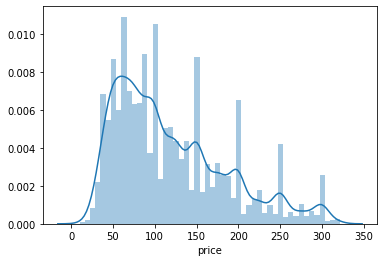

```python
sns.distplot(listings_explore.price, bins=50)
plt.show()
```

Here we see Price is a skewed right distribution with clear modes at even price values like 50, 75, 100, 125, 150, 200, 250, 300. This is due to hosts pricing their listings at even values.

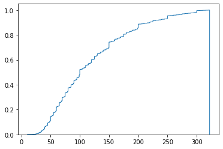

```python
# Price CDF
cdf(listings_explore, 'price')
```

```python
num_attribs.append('price')
```

## **Feature: number_of_reviews_ltm** (last twelve months) (discrete)

```python
preliminaries(listings_explore, 'number_of_reviews_ltm')
```

```
Dtype:  int64
Missing Values:  0
```

```python
# number of listings with host_since==0 and number_of_reviews_ltm==0
len(listings_explore[(listings_explore.host_since == 0) & (listings_explore.number_of_reviews_ltm == 0)])
```

```
0
```

```python
# only include number_of_reviews_ltm > 0
listings_explore = listings_explore[listings_explore.number_of_reviews_ltm > 0]
```

```python
sum_stats(listings_explore.number_of_reviews_ltm)
```

```
nobs: 21998
median: 8.0
mode: [1]
mean: 15.640785525956906
std: 18.4863398234607
minmax: (1, 282)
25% 3.0
50% 8.0
75% 23.0
skewness: 2.4239319779583917
```

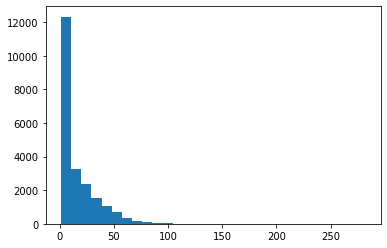

```python
plt.hist(listings_explore.number_of_reviews_ltm, bins=30)
plt.show()
```

```python
tukey_outliers(listings_explore.number_of_reviews_ltm)
```

```
(-27.0, 53.0)
```

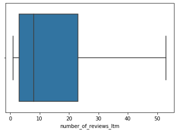

```python
# Boxplot w/o outliers
sns.boxplot(listings_explore.number_of_reviews_ltm, showfliers=False)
plt.show()
```

```python
disc_attribs.append('number_of_reviews_ltm')
```

Clean.

## **Feature: host_since** (discrete)

```python
preliminaries(listings_explore, 'host_since')
```

```
Dtype:  object
Missing Values:  4
```

We will convert host_since to how many years host has been a host.

```python
# Convert to how many years host
listings_explore['host_since'] = 2019 - listings_explore['host_since'].str[:4].astype('float64')
```

```python
# Identify indices of missing values (True)
#listings_explore.host_since.isnull().sort_values()
```

```python
# Check a missing value index
#listings_explore.loc[9339]
```

```python
# Remove missing values
#listings_explore = listings_explore[listings_explore.host_since.notnull()].copy()
```

```python
# Convert dtype to int
listings_explore['host_since'] = listings_explore.host_since.astype('float64')
```

```python
sum_stats(listings_explore.host_since.dropna())
```

```
nobs: 21994
median: 4.0
mode: [4.]
mean: 4.191324906792762
std: 2.3706946253180505
minmax: (0.0, 11.0)
25% 2.0
50% 4.0
75% 6.0
skewness: 0.17188379478247912
```

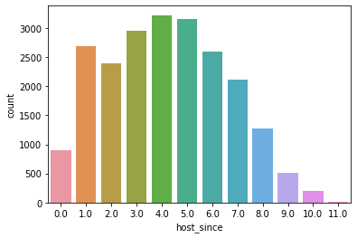

```python
# Countplot
sns.countplot(listings_explore.host_since)
plt.show()
```

Most hosts are spread rather evenly between 1 year and 7 years. 0 and 8-10 years are still significant amount. Skews slightly right.

```python
disc_attribs.append('host_since')
```

## **Feature: number_of_reviews** (discrete)

```python
preliminaries(listings_explore, 'number_of_reviews')
```

```
Dtype:  int64
Missing Values:  0
```

```python
sum_stats(listings_explore.number_of_reviews)
```

```
nobs: 21998
median: 15.0
mode: [1]
mean: 36.58668969906355
std: 52.61377490330862
minmax: (1, 609)
25% 5.0
50% 15.0
75% 47.0
skewness: 2.8773175319133326
```

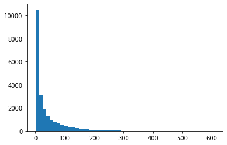

```python
plt.hist(listings_explore.number_of_reviews, bins=50)
plt.show()
```

```python
tukey_outliers(listings_explore.number_of_reviews)
```

```
(-58.0, 110.0)
```

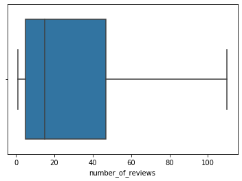

```python
# Boxplot w/o outliers
sns.boxplot(listings_explore.number_of_reviews, showfliers=False)
plt.show()
```

```python
percentile(listings_explore.number_of_reviews, 100)
```

```
89.77634330393673
```

90% of hosts have 100 reviews or less, with most closer to 0 than 100. Skews right.

```python
disc_attribs.append('number_of_reviews')
```

## **Feature: host_listings_count** (discrete) (for analysis only)

We will use host_listings_count for our analysis, but we will not include it in the model because it is not visible to guests on the app.

```python
preliminaries(listings_explore, 'host_listings_count')
```

```
Dtype:  float64
Missing Values:  4
```

A host can't have 0 listings, so this must be a mistake. We will consider 0 values to be Nan.

```python
# Amount of listings with 0 host_listings_count
len(listings_explore[listings_explore.host_listings_count == 0])
```

```
88
```

```python
# Convert 0 values to Nan
listings_explore['host_listings_count'] = listings_explore.host_listings_count.replace(0.0, np.nan).astype('float64')
```

```python
# Confirm no more 0 host_listings_count
preliminaries(listings_explore, 'host_listings_count', values=False)
```

```
Dtype:  float64
Missing Values:  92
```

```python
sum_stats(listings_explore.host_listings_count.dropna())
```

```
nobs: 21906
median: 1.0
mode: [1.]
mean: 7.1070939468638725
std: 46.887025783622555
minmax: (1.0, 1108.0)
25% 1.0
50% 1.0
75% 3.0
skewness: 17.141199112472787
```

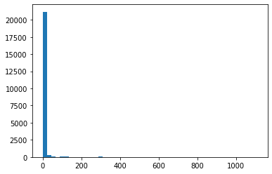

```python
plt.hist(listings_explore.host_listings_count.dropna(), bins=50)
plt.show()
```

```python
tukey_outliers(listings_explore.host_listings_count.dropna())
```

```
(-2.0, 6.0)
```

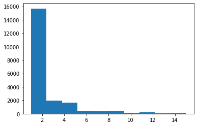

```python
# Hist of host_listings_count <= 15
plt.hist(listings_explore[listings_explore.host_listings_count <= 15].host_listings_count)
plt.show()
```

```python
percentile(listings_explore.host_listings_count.dropna(), 1)
```

```
26.360357892814754
```

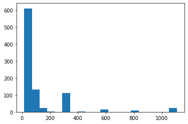

```python
# Hist of host_listings_count >= 15
plt.hist(listings_explore[listings_explore.host_listings_count > 15].host_listings_count, bins=20)
plt.show()
```

Fill missing values manually using mode since feature won't be in model.

```python
# Fill missing values (can do this now because feature will be dropped)
listings_explore['host_listings_count'] = listings_explore.host_listings_count.fillna(1.0)
```

```python
#disc_attribs.append('host_listings_count')
drop_later.append('host_listings_count')
```

## **Feature: host_total_listings_count**

There are only 92 instances with differences to host_listings_count. Because we do not know the difference in measure between host_listings_count and host_total_listings_count, we will drop host_total_listings_count.

```python
# compare listings with differences
len(listings_explore) - np.sum(listings_explore.host_total_listings_count == listings_explore.host_listings_count)
```

```
92
```

```python
listings_explore.drop(columns='host_total_listings_count', inplace=True)
dropped_cols.append('host_total_listings_count')
```

## **Feature: latitude**

```python
preliminaries(listings_explore, 'latitude')
```

```
Dtype:  float64
Missing Values:  0
```

```python
num_attribs.append('latitude')
```

## **Feature: Longitude**

```python
preliminaries(listings_explore, 'longitude')
```

```
Dtype:  float64
Missing Values:  0
```

```python
num_attribs.append('longitude')
```

## **Feature: accommodates** (discrete)

```python
preliminaries(listings_explore, 'accommodates')
```

```
Dtype:  int64
Missing Values:  0
```

```python
sum_stats(listings_explore.accommodates)
```

```
nobs: 21998
median: 2.0
mode: [2]
mean: 2.8161196472406584
std: 1.682256249145391
minmax: (1, 16)
25% 2.0
50% 2.0
75% 4.0
skewness: 2.1068170931469448
```

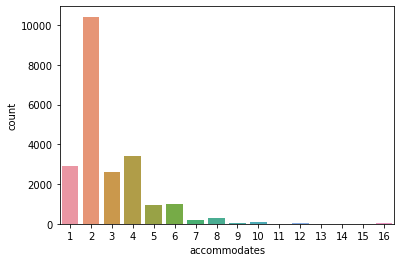

```python
sns.countplot(listings_explore.accommodates)
plt.show()
```

```python
percentile(listings_explore.accommodates, 2)
```

```
36.92153832166561
```

```python
percentile(listings_explore.accommodates, 6)
```

```
94.56086916992454
```

```python
disc_attribs.append('accommodates')
```

## **Feature: bathrooms** (discrete)

```python
preliminaries(listings_explore, 'bathrooms')
```

```
Dtype:  float64
Missing Values:  14
```

```python
sum_stats(listings_explore.bathrooms.dropna())
```

```
nobs: 21984
median: 1.0
mode: [1.]
mean: 1.1118995633187774
std: 0.36543855004584563
minmax: (0.0, 7.0)
25% 1.0
50% 1.0
75% 1.0
skewness: 4.638480022358254
```

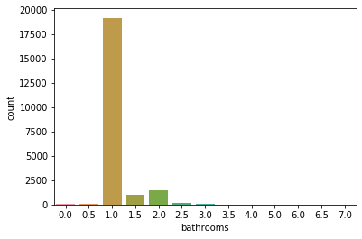

```python
sns.countplot(listings_explore.bathrooms)
plt.show()
```

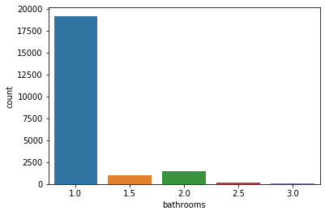

```python
# hist of bathrooms between 1 & 3
sns.countplot((listings_explore[(listings_explore.bathrooms <= 3) & (listings_explore.bathrooms >= 1)]).bathrooms)
plt.show()
```

```python
percentage_of(listings_explore.bathrooms, [1.0,1.5,2.0,2.5,3.0])
```

```
1.0    0.87
1.5    0.05
2.0    0.07
2.5    0.01
3.0    0.01
Name: bathrooms, dtype: float64
```

87% of all listings have 1 bathroom, while nearly all have 3 or less. Skews right.

```python
disc_attribs.append('bathrooms')
```

## **Feature: bedrooms** (discrete)

```python
preliminaries(listings_explore, 'bedrooms')
```

```
Dtype:  float64
Missing Values:  11
```

```python
sum_stats(listings_explore.bedrooms.dropna())
```

```
nobs: 21987
median: 1.0
mode: [1.]
mean: 1.1328967116932733
std: 0.6512091143955939
minmax: (0.0, 9.0)
25% 1.0
50% 1.0
75% 1.0
skewness: 1.6047263383243688
```

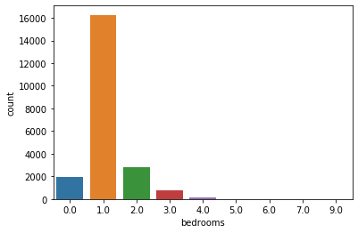

```python
sns.countplot(listings_explore.bedrooms)
plt.show()
```

```python
percentage_of(listings_explore.bedrooms, 1.0)
```

```
0.74
```

```python
percentile(listings_explore.bedrooms.dropna(), 4.0)
```

```
99.55428207577205
```

74% of listings have 1 bedroom, and nearly all have 4 or less. Skews right.

We will inspect listings with >4 bedrooms just to ensure they are not inaccurate datapoints.

```python
# View listings with >4 bedrooms
#listings_explore[listings_explore.bedrooms > 4][['bedrooms', 'beds', 'bathrooms', 'price']]
```

Although these are not completely "ordinary", as most NYC apartments have <=3 bedrooms, they are not anomalous to the point that we should consider them inaccurate. They could be large apartments, houses, etc. We will keep them in our data.

```python
disc_attribs.append('bedrooms')
```

Ready to impute.

## **Feature: beds** (discrete)

```python
preliminaries(listings_explore, 'beds')
```

```
Dtype:  float64
Missing Values:  5
```

```python
sum_stats(listings_explore.beds.dropna())
```

```
nobs: 21993
median: 1.0
mode: [1.]
mean: 1.518755967807939
std: 1.0178587474497025
minmax: (0.0, 16.0)
25% 1.0
50% 1.0
75% 2.0
skewness: 2.6337905237694295
```

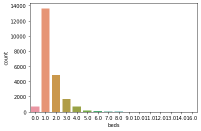

```python
sns.countplot(listings_explore.beds)
plt.show()
```

```python
percentage_of(listings_explore.beds, 1.0)
```

```
0.62
```

```python
percentile(listings_explore.beds, 4.0)
```

```
96.66560596417857
```

62% have 1 bed, while nearly all have 4 or less beds.

```python
disc_attribs.append('beds')
```

Ready to impute.

## **Feature: cleaning_fee**

```python
preliminaries(listings_explore, 'cleaning_fee')
```

```
Dtype:  object
Missing Values:  2719
```

```python
# Remove string characters, convert to float
listings_explore['cleaning_fee'] = listings_explore.cleaning_fee.str.replace('$', '', regex=False)
listings_explore['cleaning_fee'] = listings_explore.cleaning_fee.str.replace('.00', '', regex=False)
listings_explore['cleaning_fee'] = listings_explore.cleaning_fee.str.replace(',', '', regex=False)
listings_explore['cleaning_fee'] = listings_explore.cleaning_fee.astype('float64')
```

```python
sum_stats(listings_explore.cleaning_fee.dropna())
```

```
nobs: 19279
median: 50.0
mode: [50.]
mean: 59.23035427148711
std: 45.99522070457579
minmax: (0.0, 600.0)
25% 25.0
50% 50.0
75% 85.0
skewness: 1.6209885047725725
```

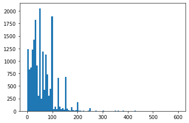

```python
plt.hist(listings_explore.cleaning_fee.dropna(), bins=100)
plt.show()
```

To visualize the distribution shape:

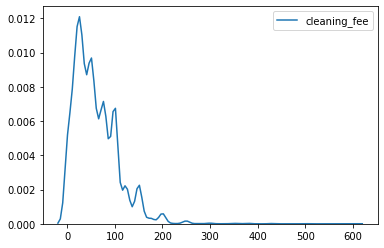

```python
sns.kdeplot(listings_explore.cleaning_fee.dropna())
plt.show()
```

```python
tukey_outliers(listings_explore.cleaning_fee.dropna())
```

```
(-65.0, 175.0)
```

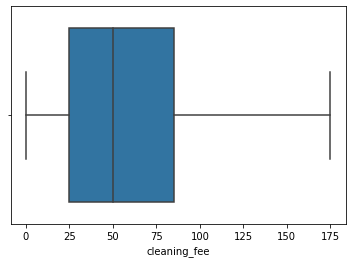

```python
# Boxplot w/o outliers
sns.boxplot(listings_explore.cleaning_fee.dropna(), showfliers=False)
plt.show()
```

```python
percentile(listings_explore.cleaning_fee.dropna(), 150)
```

```
95.63774054670886
```

Median cleaning fees is 50, 95% are 150 or less, but they can range up to 600. Skews right.

```python
num_attribs.append('cleaning_fee')
```

Ready to impute.

## **Feature: guests_included** (discrete)

```python
preliminaries(listings_explore, 'guests_included')
```

```
Dtype:  int64
Missing Values:  0
```

```python
sum_stats(listings_explore.guests_included)
```

```
nobs: 21998
median: 1.0
mode: [1]
mean: 1.5695972361123738
std: 1.0859952450199053
minmax: (1, 16)
25% 1.0
50% 1.0
75% 2.0
skewness: 3.206714798294352
```

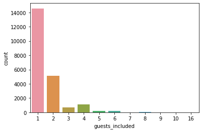

```python
sns.countplot(listings_explore.guests_included)
plt.show()
```

```python
percentage_of(listings_explore.guests_included, 1)
```

```
0.66
```

```python
percentage_of(listings_explore.guests_included, 2)
```

```
0.23
```

```python
percentile(listings_explore.guests_included, 4)
```

```
95.0609146286026
```

66% of guests included are 1, 23% are 2, and 95% of listings are 4 or less, though it skews right up to 16.

```python
disc_attribs.append('guests_included')
```

Clean.

## Feature: extra_people (discrete)

Cost per additional person.

```python
preliminaries(listings_explore, 'extra_people')
```

```
Dtype:  object
Missing Values:  0
```

```python
# Remove string characters, convert to float
listings_explore['extra_people'] = listings_explore.extra_people.str.replace('$', '', regex=False)
listings_explore['extra_people'] = listings_explore.extra_people.str.replace('.00', '', regex=False)
listings_explore['extra_people'] = listings_explore.extra_people.str.replace(',', '', regex=False)
listings_explore['extra_people'] = listings_explore.extra_people.astype('float64')
```

```python
sum_stats(listings_explore.extra_people)
```

```
nobs: 21998
median: 10.0
mode: [0.]
mean: 17.015410491862898
std: 24.58359286094277
minmax: (0.0, 300.0)
25% 0.0
50% 10.0
75% 25.0
skewness: 4.385639195835524
```

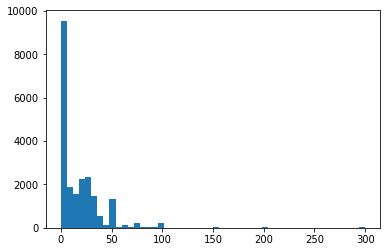

```python
plt.hist(listings_explore.extra_people, bins=50)
plt.show()
```

```python
tukey_outliers(listings_explore.extra_people)
```

```
(-37.5, 62.5)
```

```python
disc_attribs.append('extra_people')
```

## **Feature: minimum_nights** (discrete)

```python
preliminaries(listings_explore, 'minimum_nights')
```

```
Dtype:  int64
Missing Values:  0
```

How there are minimum_nights values above 180 when the MAXIMUM airbnb allows is 6 months (180 days)? One solution is to drop the rows for which minimum_nights exceeds 180, another is to drop the feature altogether.

Because we are measuring standard Airbnb's, we are not measuring long-term Airbnb's. Therefore we should drop all rows whose minimum_nights exceed 7 nights. This has been chosen because a week seems like a reasonable amount of time for a minimum for a standard type of room that hasn't been heavily discounted due to quantity of long-term stay.

```python
# only include minimum_nights <= 7
listings_explore = listings_explore[listings_explore.minimum_nights <= 7].copy()
```

```python
sum_stats(listings_explore.minimum_nights)
```

```
nobs: 19506
median: 2.0
mode: [2]
mean: 2.505280426535425
std: 1.5215104025115558
minmax: (1, 7)
25% 1.0
50% 2.0
75% 3.0
skewness: 1.2214395564997413
```

```python
tukey_outliers(listings_explore.minimum_nights)
```

```
(-2.0, 6.0)
```

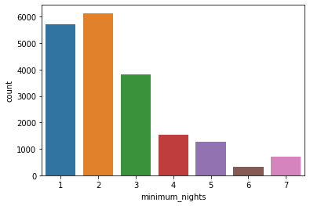

```python
sns.countplot(listings_explore.minimum_nights)
plt.show()
```

Most listings have 1-3 night minimum, but it ranges up to 7, with outliers at 6+. Skews right.

```python
disc_attribs.append('minimum_nights')
```

Ready to impute.

## **Feature: maximum_nights** (discrete)

```python
preliminaries(listings_explore, 'maximum_nights')
```

```
Dtype:  int64
Missing Values:  0
```

How there are maximum_nights values above 180 when the MAXIMUM airbnb allows is 6 months (180 days)? One solution is to drop the rows for which maximum_nights exceeds 180, another is to drop the feature altogether.

Maximum nights need not be filtered because we ensured minimum nights cannot exceed 7 nights, so pricing should remain short-term stay price regardless of how high the option can go.

```python
sum_stats(listings_explore.maximum_nights)
```

```
nobs: 19506
median: 180.0
mode: [1125]
mean: 555.6846611299087
std: 706.7853914080637
minmax: (1, 60000)
25% 28.0
50% 180.0
75% 1125.0
skewness: 31.337019025454545
```

```python
tukey_outliers(listings_explore.maximum_nights)
```

```
(-1617.5, 2770.5)
```

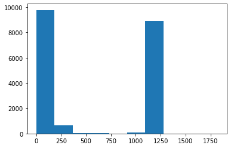

```python
plt.hist(listings_explore[listings_explore.maximum_nights <= 2000].maximum_nights)
plt.show()
```

There is a surprisingly high mode at 1125 maximum_nights with a large gap before and after that number. This may be the maximum allowable by the Airbnb fill-in field. We will use 180 as a bin for any number of nights above 180 because 6 months is the max length of stay for short-term Airbnb as per policy.

```python
# Cap maximum_nights at 180
listings_explore['maximum_nights'].values[listings_explore.maximum_nights > 180] = 180
```

```python
sum_stats(listings_explore.maximum_nights)
```

```
nobs: 19506
median: 180.0
mode: [180]
mean: 106.64252025017943
std: 76.91872495258504
minmax: (1, 180)
25% 28.0
50% 180.0
75% 180.0
skewness: -0.16872493511923184
```

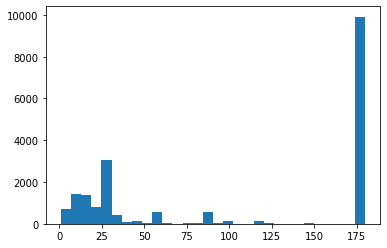

```python
plt.hist(listings_explore.maximum_nights, bins=30)
plt.show()
```

```python
percentage_of(listings_explore.maximum_nights, 180)
```

```
0.51
```

```python
percentile(listings_explore.maximum_nights, 50)
```

```
41.05147134215113
```

```python
disc_attribs.append('maximum_nights')
```

**Features: minimum_minimum_nights, maximum_minimum_nights, minimum_maximum_nights, maximum_maximum_nights, minimum_nights_avg_ntm, maximum_nights_avg_ntm**

We will drop these specific features in lieu of the features: minimum_nights and maximum_nights. NTM means 'next twelve months.'

```python
listings_explore.drop(columns=['minimum_minimum_nights', 'maximum_minimum_nights', 'minimum_maximum_nights', 'maximum_maximum_nights', 'minimum_nights_avg_ntm', 'maximum_nights_avg_ntm'], inplace=True)
dropped_cols.extend(['minimum_minimum_nights', 'maximum_minimum_nights', 'minimum_maximum_nights', 'maximum_maximum_nights', 'minimum_nights_avg_ntm', 'maximum_nights_avg_ntm'])
```

## **Feature: availability_30** (discrete)

```python
preliminaries(listings_explore, 'availability_30')
```

```
Dtype:  int64
Missing Values:  0
```

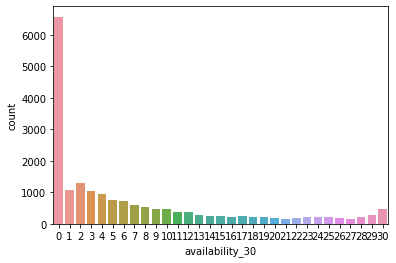

```python
sns.countplot(listings_explore.availability_30)
plt.show()
```

Mode is at 0 availability_30 with small amounts ranging from 1-30. Skews right.

```python
disc_attribs.append('availability_30')
```

## **Feature: availability_60**

```python
preliminaries(listings_explore, 'availability_60')
```

```
Dtype:  int64
Missing Values:  0
```

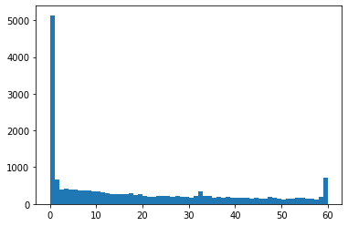

```python
plt.hist(listings_explore.availability_60, bins=60)
plt.show()
```

Mode at 0 with a small spike at 60. Skews right.

```python
disc_attribs.append('availability_60')
```

## **Feature: availability_90**

```python
preliminaries(listings_explore, 'availability_90')
```

```
Dtype:  int64
Missing Values:  0
```

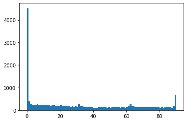

```python
plt.hist(listings_explore.availability_90, bins=90)
plt.show()
```

Mode at 0 with small spike at 90, skews right.

```python
disc_attribs.append('availability_90')
```

## **Feature: availability_365**

```python
preliminaries(listings_explore, 'availability_365')
```

```
Dtype:  int64
Missing Values:  0
```

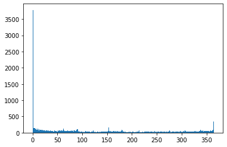

```python
plt.hist(listings_explore.availability_365, bins=365)
plt.show()
```

Mode at 0 with small spike at 365, skews right.

```python
disc_attribs.append('availability_365')
```

## **Features: first_review, last_review**

Feature first_review dropped in lieu of feature number_of_reviews because that covers all reviews, and host_since measures how long a host has been hosting.

Feature last_review dropped in lieu of feature number_of_reviews_ltm because that covers the amount of recent reviews for potential renters to see.

```python
listings_explore.drop(columns=['first_review', 'last_review'], inplace=True)
dropped_cols.extend(['first_review', 'last_review'])
```

## Feature: review_scores_rating (discrete)

```python
preliminaries(listings_explore, 'review_scores_rating')
```

```
Dtype:  float64
Missing Values:  259
```

```python
sum_stats(listings_explore.review_scores_rating.dropna())
```

```
nobs: 19247
median: 96.0
mode: [100.]
mean: 94.31511404374707
std: 7.138444164094625
minmax: (20.0, 100.0)
25% 92.0
50% 96.0
75% 99.0
skewness: -3.7195392855576648
```

```python
tukey_outliers(listings_explore.review_scores_rating.dropna())
```

```
(81.5, 109.5)
```

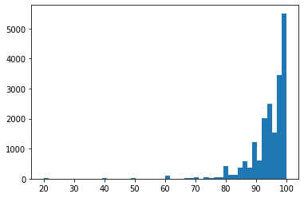

```python
plt.hist(listings_explore.review_scores_rating.dropna(), bins=50)
plt.show()
```

```python
percentage_of(listings_explore.review_scores_rating, 100)
```

```
0.23
```

```python
1 - percentile(listings_explore.review_scores_rating, 90)
```

```
-15.669229980518814
```

```python
disc_attribs.append('review_scores_rating')
```

## **Feature: review_scores_accuracy** (Discrete)

```python
preliminaries(listings_explore, 'review_scores_accuracy')
```

```
Dtype:  float64
Missing Values:  261
```

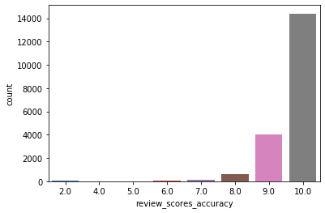

```python
sns.countplot(listings_explore.review_scores_accuracy.dropna())
plt.show()
```

Mode at 10, some at 9, the rest small down to 2. Skews left.

```python
disc_attribs.append('review_scores_accuracy')
```